```python
# Library
import pandas as pd
import numpy as np
import seaborn as sns
import matplotlib.pyplot as plt
from sklearn.decomposition import PCA
from sklearn.preprocessing import StandardScaler
from sklearn.pipeline import make_pipeline
from sklearn.cluster import KMeans
from sklearn.metrics import adjusted_rand_score
```

```python
# Data
conso_df = pd.read_csv("backup_files/analytical_base_table.csv")
item_df = pd.read_csv("backup_files/item_data.csv")
conso_df.set_index("CustomerID", inplace = True)
```

The goal is to cluster customers according to their purchasing patterns. I use two datasets to do so. The first one contains aggregate variables concerning a consumer purchases. The other contains, for each customer, how many time a product has been bought. Since the latter dataset is very big due to the numer of products, I am performing a PCA. The two K-mean clustering algorithms have an adjusted RAND score of 0.75.

# Data

conso_df is a consumer-level dataset. It contains aggregate variables concerning a consumer purchases.

```python
conso_df.head()
```

[output not shown]

item_df is a consumer-level dataset. For each consumer, it contains how many time a product has been bought by the consumer. It is a very sparse dataset. I will reduce its dimensionality using PCA.

```python
item_df.head()
```

|  | CustomerID | 10002 | 10120 | 10125 | 10133 | 10135 | 11001 | 15034 | 15036 | 15039 | ... | 90192 | 90201A | 90201B | 90201C | 90201D | 90202D | 90204 | C2 | M | POST |
| --- | --- | --- | --- | --- | --- | --- | --- | --- | --- | --- | --- | --- | --- | --- | --- | --- | --- | --- | --- | --- | --- |
| 0 | 12347 | 0 | 0 | 0 | 0 | 0 | 0 | 0 | 0 | 0 | ... | 0 | 0 | 0 | 0 | 0 | 0 | 0 | 0 | 0 | 0 |
| 1 | 12348 | 0 | 0 | 0 | 0 | 0 | 0 | 0 | 0 | 0 | ... | 0 | 0 | 0 | 0 | 0 | 0 | 0 | 0 | 0 | 4 |
| 2 | 12349 | 0 | 0 | 0 | 0 | 0 | 0 | 0 | 0 | 0 | ... | 0 | 0 | 0 | 0 | 0 | 0 | 0 | 0 | 0 | 1 |
| 3 | 12350 | 0 | 0 | 0 | 0 | 0 | 0 | 0 | 0 | 0 | ... | 0 | 0 | 0 | 0 | 0 | 0 | 0 | 0 | 0 | 1 |
| 4 | 12352 | 0 | 0 | 0 | 0 | 0 | 0 | 0 | 0 | 0 | ... | 0 | 0 | 0 | 0 | 0 | 0 | 0 | 0 | 3 | 5 |

5 rows × 2575 columns

# PCA to reduce the dimensionality of the item data.

```python
# Scale the data and apply PCA
item_data_scaled = StandardScaler().fit_transform(item_df.drop("CustomerID", axis = 1))
pca = PCA()
PC_items = pca.fit(item_data_scaled)
```

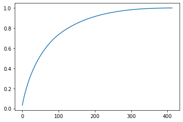

```python
# Plot of cumulative explained variance
cum_var = np.cumsum(pca.explained_variance_ratio_)
plt.plot(cum_var)
```

```python
# Pick the number of components such that 80% of the variation in the data is explained
index_component = np.where((cum_var < 0.8)==False)[0][0]
```

```python
# PCA with picked number of components
pca_2 = PCA(n_components = index_component)
pca_2.fit(item_data_scaled)
PC_items = pca_2.fit_transform(item_data_scaled)
```

```python
PC_items
```

```
array([[ 5.87614045,  4.82891619, -0.49556516, ..., -0.29139273,
         0.03576437, -0.17505665],
       [-4.2198428 ,  1.22616434, -1.88189532, ..., -0.50056108,
        -1.5434379 ,  1.01978292],
       [-1.26084397,  2.38767519, -0.07313606, ..., -0.79577958,
         0.12731984,  1.38156402],
       ...,
       [-5.21816214,  3.64839601,  2.50644712, ..., -0.01356345,
        -0.08450173,  0.31617189],
       [-4.93611857,  3.02158968, -1.5071006 , ..., -0.97755993,
         4.16727066,  0.7729973 ],
       [-6.04237174, -0.29137491, -0.67404122, ...,  0.3328867 ,
        -0.13059906, -0.54210854]])
```

```python
# Put the result in a dataframe
pca_df = pd.DataFrame(PC_items, columns = [f"PC{i + 1}" for i in range(index_component)])
pca_df.index = item_df.CustomerID
```

```python
# Join conso_df with pca_df
pca_df = conso_df.join(pca_df)
```

```python
pca_df.head()
```

| CustomerID | total_transactions | total_products | total_unique_products | avg_product_value | total_sales | min_cart_value | max_cart_value | avg_cart_value | PC1 | PC2 | ... | PC118 | PC119 | PC120 | PC121 | PC122 | PC123 | PC124 | PC125 | PC126 | PC127 |
| --- | --- | --- | --- | --- | --- | --- | --- | --- | --- | --- | --- | --- | --- | --- | --- | --- | --- | --- | --- | --- | --- |
| 12347 | 7 | 182 | 103 | 23.681319 | 4310.00 | 224.82 | 1294.32 | 615.714286 | 5.876140 | 4.828916 | ... | 0.865173 | -0.702821 | -0.038654 | 0.200905 | 0.530798 | -0.321758 | 0.308798 | -0.291393 | 0.035764 | -0.175057 |
| 12348 | 4 | 31 | 22 | 57.975484 | 1797.24 | 227.44 | 892.80 | 449.310000 | -4.219843 | 1.226164 | ... | -0.786140 | 0.911053 | 1.117424 | 0.790827 | 0.730546 | 1.650160 | -0.311626 | -0.500561 | -1.543438 | 1.019783 |
| 12349 | 1 | 73 | 73 | 24.076027 | 1757.55 | 1757.55 | 1757.55 | 1757.550000 | -1.260844 | 2.387675 | ... | 3.654466 | 0.836773 | 1.632948 | -2.966335 | 5.432100 | -0.873284 | -0.155985 | -0.795780 | 0.127320 | 1.381564 |
| 12350 | 1 | 17 | 17 | 19.670588 | 334.40 | 334.40 | 334.40 | 334.400000 | -4.929315 | -0.714862 | ... | -1.098453 | 0.531652 | 0.429027 | -0.919918 | -0.503685 | -0.926167 | -0.495513 | -0.486471 | 0.939907 | 1.507387 |
| 12352 | 8 | 85 | 59 | 29.482824 | 2506.04 | 120.33 | 840.30 | 313.255000 | -2.053126 | 2.110909 | ... | -2.674533 | -9.182151 | -6.047264 | -0.636358 | -0.187099 | -2.488531 | 5.382939 | -4.539227 | 3.015732 | -3.779266 |

5 rows × 135 columns

# Clustering algorithm

We will look at 2 possible feature sets and compare the clusters created from them. We'll try:

1. Only purchase pattern features (**"Conso DF"**)
2. Purchase pattern features + principal component features from items (**"PCA DF"**)

## Purchase pattern features clustering

```python
# Get the clusters based on the two datasets
# K-Means model pipeline
dic_df = {"conso_df": conso_df, "pca_df":pca_df}
for df in dic_df.values():
    k_means = make_pipeline(StandardScaler(),
                        KMeans(n_clusters=3, random_state=123))
    # Fit K-Means pipeline
    k_means.fit(df)
    # Get the cluster predictions
    # Save clusters to base_df
    df['cluster'] = k_means.predict(df)

    # Display first 5 rows of base_df
    df.head()
```

## How similar are the two clusters?

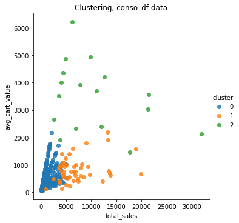

[figure not shown]

```python
# Plot the two clusters
for k, df in dic_df.items():
    sns.lmplot(x='total_sales', y='avg_cart_value', hue='cluster',
           data=conso_df, fit_reg=False)
    plt.title(f"Clustering, {k} data")
    plt.show()
```

```python
# Similary between base_df.cluster and pca_df.cluster
adjusted_rand_score(conso_df.cluster, pca_df.cluster)
```

```
0.7548601323062277
```

The two clustering algorithms are pretty similar.